# Exploratory Data Analysis and Visualization Using PySpark - Azizha Zeinita

```python
import pandas as pd
import numpy as np
from pyspark.sql import SparkSession
from pyspark import SparkConf, SparkContext
from pyspark.sql import HiveContext
from pyspark.sql.functions import date_format, when, col, to_timestamp, substring, to_date, unix_timestamp, dayofweek, rank
from pyspark.sql.functions import *
from pyspark.sql.types import IntegerType,BooleanType,DateType
import pyspark.sql.functions as F
from pyspark.sql.window import Window

import matplotlib.pyplot as plt
import seaborn as sns
%matplotlib inline
```

## 1) Read the chicago_crimes Hive table into PySpark

```python
spark = SparkSession.builder.appName('ChicagoCrime').enableHiveSupport().getOrCreate()
spark.conf.set ("spark.sql.repl.eagerEval.enabled", True)
```

```python
!hdfs dfs -ls -R /user/azizhazeinita/crimes
```

```
WARNING: log4j.properties is not found. HADOOP_CONF_DIR may be incomplete.
Java HotSpot(TM) 64-Bit Server VM warning: ignoring option MaxPermSize=512M; support was removed in 8.0
-rw-r--r--   3 azizhazeinita azizhazeinita 1766601462 2022-02-12 09:50 /user/azizhazeinita/crimes/crimes.csv
-rw-r--r--   3 azizhazeinita azizhazeinita      53917 2022-02-12 11:20 /user/azizhazeinita/crimes/summary_11.csv
```

```python
df = spark.read.csv("/user/azizhazeinita/crimes/crimes.csv", inferSchema=True, header=True)
```

```python
df.printSchema()
```

```
root
 |-- ID: integer (nullable = true)
 |-- Case Number: string (nullable = true)
 |-- Date: string (nullable = true)
 |-- Block: string (nullable = true)
 |-- IUCR: string (nullable = true)
 |-- Primary Type: string (nullable = true)
 |-- Description: string (nullable = true)
 |-- Location Description: string (nullable = true)
 |-- Arrest: boolean (nullable = true)
 |-- Domestic: boolean (nullable = true)
 |-- Beat: integer (nullable = true)
 |-- District: integer (nullable = true)
 |-- Ward: integer (nullable = true)
 |-- Community Area: integer (nullable = true)
 |-- FBI Code: string (nullable = true)
 |-- X Coordinate: integer (nullable = true)
 |-- Y Coordinate: integer (nullable = true)
 |-- Year: integer (nullable = true)
 |-- Updated On: string (nullable = true)
 |-- Latitude: double (nullable = true)
 |-- Longitude: double (nullable = true)
 |-- Location: string (nullable = true)
```

```python
new_names = ['id', 'case_number', 'date_', 'block', 'iucr', 'primary_type', 'description', 'location_description', 'arrest', 'domestic', 'beat', 'district', 'ward', 'community_area', 'fbi_code', 'x_oordinate', 'y_coordinate', 'year', 'updated_on', 'latitude', 'longitude', 'location']
df = df.toDF(*new_names)
```

```python
pd.DataFrame(df.head(5), columns=df.columns)
```

|  | id | case_number | date_ | block | iucr | primary_type | description | location_description | arrest | domestic | ... | ward | community_area | fbi_code | x_oordinate | y_coordinate | year | updated_on | latitude | longitude | location |
| --- | --- | --- | --- | --- | --- | --- | --- | --- | --- | --- | --- | --- | --- | --- | --- | --- | --- | --- | --- | --- | --- |
| 0 | 10224738 | HY411648 | 09/05/2015 01:30:00 PM | 043XX S WOOD ST | 0486 | BATTERY | DOMESTIC BATTERY SIMPLE | RESIDENCE | False | True | ... | 12 | 61 | 08B | 1165074.0 | 1875917.0 | 2015 | 02/10/2018 03:50:01 PM | 41.815117 | -87.670000 | (41.815117282, -87.669999562) |
| 1 | 10224739 | HY411615 | 09/04/2015 11:30:00 AM | 008XX N CENTRAL AVE | 0870 | THEFT | POCKET-PICKING | CTA BUS | False | False | ... | 29 | 25 | 06 | 1138875.0 | 1904869.0 | 2015 | 02/10/2018 03:50:01 PM | 41.895080 | -87.765400 | (41.895080471, -87.765400451) |
| 2 | 11646166 | JC213529 | 09/01/2018 12:01:00 AM | 082XX S INGLESIDE AVE | 0810 | THEFT | OVER $500 | RESIDENCE | False | True | ... | 8 | 44 | 06 | NaN | NaN | 2018 | 04/06/2019 04:04:43 PM | NaN | NaN | None |
| 3 | 10224740 | HY411595 | 09/05/2015 12:45:00 PM | 035XX W BARRY AVE | 2023 | NARCOTICS | POSS: HEROIN(BRN/TAN) | SIDEWALK | True | False | ... | 35 | 21 | 18 | 1152037.0 | 1920384.0 | 2015 | 02/10/2018 03:50:01 PM | 41.937406 | -87.716650 | (41.937405765, -87.716649687) |
| 4 | 10224741 | HY411610 | 09/05/2015 01:00:00 PM | 0000X N LARAMIE AVE | 0560 | ASSAULT | SIMPLE | APARTMENT | False | True | ... | 28 | 25 | 08A | 1141706.0 | 1900086.0 | 2015 | 02/10/2018 03:50:01 PM | 41.881903 | -87.755121 | (41.881903443, -87.755121152) |

5 rows × 22 columns

### Print basic summary statistics of the data set

```python
df.summary().toPandas()
```

|  | summary | id | case_number | date_ | block | iucr | primary_type | description | location_description | beat | ... | ward | community_area | fbi_code | x_oordinate | y_coordinate | year | updated_on | latitude | longitude | location |
| --- | --- | --- | --- | --- | --- | --- | --- | --- | --- | --- | --- | --- | --- | --- | --- | --- | --- | --- | --- | --- | --- |
| 0 | count | 7485100 | 7485096 | 7485100 | 7485100 | 7485100 | 7485100 | 7485100 | 7476132 | 7485100 | ... | 6870258 | 6871621 | 7485100 | 7408415 | 7408415 | 7485100 | 7485100 | 7408415 | 7408415 | 7408415 |
| 1 | mean | 6795517.473227879 | 305161.84210526315 | None | None | 1123.8907440569164 | None | None | None | 1187.2417465364524 | ... | 22.728666085029122 | 37.53421863633049 | 12.13927110951172 | 1164570.7964354048 | 1885738.882124854 | 2009.4538750317297 | None | 41.842063606371795 | -87.67160601731626 | None |
| 2 | stddev | 3369779.329343881 | 134932.50160327618 | None | None | 813.0628226108395 | None | None | None | 702.9575434006675 | ... | 13.836680927859483 | 21.541000915110477 | 7.3363902593066275 | 16850.112682726674 | 32278.173325695494 | 5.872968449273444 | None | 0.08880474423995277 | 0.061089755474982056 | None |
| 3 | min | 634 | .JB299184 | 01/01/2001 01:00:00 AM | 0000X E 100 PL | 0110 | ARSON | $300 AND UNDER | "CTA ""L"" PLATFORM" | 111 | ... | 1 | 0 | 01A | 0 | 0 | 2001 | 01/01/2007 07:32:02 AM | 36.619446395 | -91.686565684 | (36.619446395, -91.686565684) |
| 4 | 25% | 3675625 | 161884.0 | None | None | 560.0 | None | None | None | 621 | ... | 10 | 23 | 6.0 | 1152956 | 1859077 | 2004 | None | 41.768727829 | -87.713763476 | None |
| 5 | 50% | 6790269 | 318876.0 | None | None | 860.0 | None | None | None | 1034 | ... | 23 | 32 | 11.0 | 1166069 | 1890681 | 2009 | None | 41.855761887 | -87.665933289 | None |
| 6 | 75% | 9749082 | 413567.0 | None | None | 1320.0 | None | None | None | 1731 | ... | 34 | 57 | 18.0 | 1176365 | 1909231 | 2014 | None | 41.906730673 | -87.628227614 | None |
| 7 | max | 12615139 | ZZZ199957 | 12/31/2021 12:55:00 AM | XX UNKNOWN | 9901 | WEAPONS VIOLATION | WIREROOM/SPORTS | YMCA | 2535 | ... | 50 | 77 | 26 | 1205119 | 1951622 | 2022 | 12/31/2021 03:53:44 PM | 42.022910333 | -87.524529378 | (42.022910333, -87.677192004) |

8 rows × 21 columns

### Drop the columns beat, ward, latitude and longitude columns

```python
df = df.drop("beat", "ward", "latitude", "longitude")
```

```python
df.printSchema()
```

```
root
 |-- id: integer (nullable = true)
 |-- case_number: string (nullable = true)
 |-- date_: string (nullable = true)
 |-- block: string (nullable = true)
 |-- iucr: string (nullable = true)
 |-- primary_type: string (nullable = true)
 |-- description: string (nullable = true)
 |-- location_description: string (nullable = true)
 |-- arrest: boolean (nullable = true)
 |-- domestic: boolean (nullable = true)
 |-- district: integer (nullable = true)
 |-- community_area: integer (nullable = true)
 |-- fbi_code: string (nullable = true)
 |-- x_oordinate: integer (nullable = true)
 |-- y_coordinate: integer (nullable = true)
 |-- year: integer (nullable = true)
 |-- updated_on: string (nullable = true)
 |-- location: string (nullable = true)
```

### Convert remaining columns to appropriate data types. Make your best assumptions by sampling the data. View schema again to ensure that data types have been converted.

```python
df = df.withColumn("arrest", df["arrest"].cast(BooleanType()))
df = df.withColumn("domestic", df["domestic"].cast(BooleanType()))
df = df.withColumn("year", df["year"].cast(IntegerType()))
df = df.withColumn("date_2", df.date_.substr(1,10))
df = df.withColumn("date_2",to_date(col("date_2"),"MM/dd/yyyy").alias("date"))
df = df.withColumn("DoW", date_format(col("date_2"), "EEEE"))
```

### Add a month column and community name (from metadata) to the dataset

```python
from pyspark.sql.functions import unix_timestamp
from pyspark.sql.functions import from_unixtime

df = df.withColumn("month_name", date_format(col("date_2"), "MMMMM"))
df = df.withColumn("month", df.date_.substr(1,2))

conditions = when(col("Community_area") == 1, "Rogers Park").when(col("Community_area") == 2, "West Ridge").when(col("Community_area") == 3, "Uptown").when(col("Community_area") == 4, "Lincoln Square").when(col("Community_area") == 5, "North Center").when(col("Community_area") == 6, "Lakeview").when(col("Community_area") == 7, "Lincoln Park").when(col("Community_area") == 8, "Near North Side").when(col("Community_area") == 9, "Edison Park").when(col("Community_area") == 10, "Norwood Park").when(col("Community_area") == 11, "Jefferson Park").when(col("Community_area") == 12, "Forest Glen").when(col("Community_area") == 13, "North Park").when(col("Community_area") == 14, "Albany Park").when(col("Community_area") == 15, "Portage Park").when(col("Community_area") == 16, "Irving Park").when(col("Community_area") == 17, "Dunning").when(col("Community_area") == 18, "Montclare").when(col("Community_area") == 19, "Belmont Cragin").when(col("Community_area") == 20, "Hermosa").when(col("Community_area") == 21, "Avondale").when(col("Community_area") == 22, "Logan Square").when(col("Community_area") == 23, "Humboldt Park").when(col("Community_area") == 24, "West Town").when(col("Community_area") == 25, "Austin").when(col("Community_area") == 26, "West Garfield Park").when(col("Community_area") == 27, "East Garfield Park").when(col("Community_area") == 28, "Near West Side").when(col("Community_area") == 29, "North Lawndale").when(col("Community_area") == 30, "South Lawndale").when(col("Community_area") == 31, "Lower West Side").when(col("Community_area") == 32, "Loop").when(col("Community_area") == 33, "Near South Side").when(col("Community_area") == 34, "Armour Square").when(col("Community_area") == 35, "Douglas").when(col("Community_area") == 36, "Oakland").when(col("Community_area") == 37, "Fuller Park").when(col("Community_area") == 38, "Grand Boulevard").when(col("Community_area") == 39, "Kenwood").when(col("Community_area") == 40, "Washington Park").when(col("Community_area") == 41, "Hyde Park").when(col("Community_area") == 42, "Woodlawn").when(col("Community_area") == 43, "South Shore").when(col("Community_area") == 44, "Chatham").when(col("Community_area") == 45, "Avalon Park").when(col("Community_area") == 46, "South Chicago").when(col("Community_area") == 47, "Burnside").when(col("Community_area") == 48, "Calumet Heights").when(col("Community_area") == 49, "Roseland").when(col("Community_area") == 50, "Pullman").when(col("Community_area") == 51, "South Deering").when(col("Community_area") == 52, "East Side").when(col("Community_area") == 53, "West Pullman").when(col("Community_area") == 54, "Riverdale").when(col("Community_area") == 55, "Hegewisch").when(col("Community_area") == 56, "Garfield Ridge").when(col("Community_area") == 57, "Archer Heights").when(col("Community_area") == 58, "Brighton Park").when(col("Community_area") == 59, "McKinley Park").when(col("Community_area") == 60, "Bridgeport").when(col("Community_area") == 61, "New City").when(col("Community_area") == 62, "West Elsdon").when(col("Community_area") == 63, "Gage Park").when(col("Community_area") == 64, "Clearing").when(col("Community_area") == 65, "West Lawn").when(col("Community_area") == 66, "Chicago Lawn").when(col("Community_area") == 67, "West Englewood").when(col("Community_area") == 68, "Englewood").when(col("Community_area") == 69, "Greater Grand Crossing").when(col("Community_area") == 70, "Ashburn").when(col("Community_area") == 71, "Auburn Gresham").when(col("Community_area") == 72, "Beverly").when(col("Community_area") == 73, "Washington Heights").when(col("Community_area") == 74, "Mount Greenwood").when(col("Community_area") == 75, "Morgan Park").when(col("Community_area") == 76, "O'Hare").otherwise("Edgewater")
df = df.withColumn("community_name", conditions)
```

```python
df = df.withColumn("month_year", concat(col("year"), lit("-"), col("month")))
```

```python
pd.DataFrame(df.head(5), columns=df.columns)
```

[output not shown]

5 rows × 23 columns

## 2) Explore data by crime attributes

### Group and count crimes where description begins with the word “aggravated”

```python
df.filter(df.description.startswith('AGGRAVATED')).count()
```

```
365925
```

```python
df.filter(df.location_description == 'APARTMENT').groupby('primary_type').count().orderBy(["count"], ascending=[0]).show()
```

```
+--------------------+------+
|        primary_type| count|
+--------------------+------+
|             BATTERY|283142|
|            BURGLARY|119638|
|     CRIMINAL DAMAGE| 93058|
|               THEFT| 85026|
|       OTHER OFFENSE| 74725|
|             ASSAULT| 64095|
|  DECEPTIVE PRACTICE| 29730|
|   CRIMINAL TRESPASS| 16461|
|           NARCOTICS| 13187|
|OFFENSE INVOLVING...| 12928|
| CRIM SEXUAL ASSAULT|  6990|
|             ROBBERY|  5156|
|   WEAPONS VIOLATION|  5065|
|         SEX OFFENSE|  4151|
|PUBLIC PEACE VIOL...|  2194|
|CRIMINAL SEXUAL A...|  1423|
|               ARSON|  1045|
| MOTOR VEHICLE THEFT|  1021|
|            HOMICIDE|   990|
|          KIDNAPPING|   615|
+--------------------+------+
only showing top 20 rows
```

### The maximum number of weapons violations per month that occurred in 2020.

```python
df.filter(df.primary_type == "WEAPONS VIOLATION").filter(df.year == "2020").groupby('month_name').count().orderBy(["count"], ascending=[0]).dropna().show()
```

```
+----------+-----+
|month_name|count|
+----------+-----+
|    August|  983|
| September|  831|
|   October|  806|
|      July|  804|
|       May|  792|
|      June|  782|
|  November|  777|
|  December|  765|
|   January|  490|
|     April|  474|
|     March|  464|
|  February|  461|
+----------+-----+
```

### Percentage of The Domestic Crimes Led to An Arrest

```python
dv_count = df.filter(df.primary_type == "DOMESTIC VIOLENCE").filter(df.arrest == "true").count()
arrest_count = df.filter(df.primary_type == "DOMESTIC VIOLENCE").count()
(dv_count/arrest_count)*100
```

```
100.0
```

## 3. Explore data by date and time

### Day of the week and month that have the most and the least crimes on average

```python
#The most crimes on average
df.groupby("DoW", "month_name").count().sort("count").orderBy(["count"], ascending=[0]).show(1)
```

```
+------+----------+------+
|   DoW|month_name| count|
+------+----------+------+
|Friday|    August|103339|
+------+----------+------+
only showing top 1 row
```

```python
#The least crimes on average
df.groupby("DoW", "month_name").count().sort("count").orderBy(["count"], ascending=[1]).dropna().show(1)
```

[output not shown]

### Tha date tha had the most number of homicides in the dataset and number of days passed between this date and the next highest number of homicides

```python
df.filter(df.primary_type == "HOMICIDE").groupby('date_2').count().orderBy(["count", "date_2"], ascending=[0]).dropna().show()
```

```
+----------+-----+
|    date_2|count|
+----------+-----+
|2020-05-31|   19|
|2003-07-05|   10|
|2015-09-02|   10|
|2020-07-04|    9|
|2016-09-05|    9|
|2016-02-04|    9|
|2021-06-15|    9|
|2001-07-23|    8|
|2017-07-05|    8|
|2021-09-27|    8|
|2017-03-30|    8|
|2020-04-07|    8|
|2017-07-14|    8|
|2020-06-28|    8|
|2016-08-23|    8|
|2021-04-04|    8|
|2016-08-08|    8|
|2004-08-01|    8|
|2003-05-20|    8|
|2020-05-30|    8|
+----------+-----+
only showing top 20 rows
```

#### ANSWER: Days passed in number of homicides between 2020-05-31 and 2015-09-02 is 1733 days

### Plot a monthly time series line chart of all crimes for the last 3 years

```python
year1 = [2018,2019,2020]
df2 = df.filter(df.year.isin(year1)).groupBy("year", "month").count().orderBy(["year", "month"],ascending = [1,1])
df2.show()
```

```
+----+-----+-----+
|year|month|count|
+----+-----+-----+
|2018|   01|20513|
|2018|   02|17348|
|2018|   03|21229|
|2018|   04|21139|
|2018|   05|24734|
|2018|   06|24240|
|2018|   07|25266|
|2018|   08|25458|
|2018|   09|23100|
|2018|   10|22842|
|2018|   11|20679|
|2018|   12|21989|
|2019|   01|19691|
|2019|   02|18419|
|2019|   03|20429|
|2019|   04|21023|
|2019|   05|23649|
|2019|   06|23610|
|2019|   07|24855|
|2019|   08|24404|
+----+-----+-----+
only showing top 20 rows
```

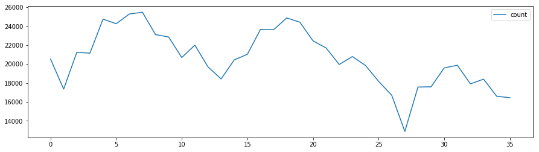

```python
pdf = df2.toPandas()
pdf.plot(y="count", figsize=(15,4), style="-")
```

### Plot a year over year comparison for 3 years (2018, 2019, 2020) by top 5 crime types.

```python
year1 = [2018,2019,2020]
df3 = df.filter(df.year.isin(year1)).groupBy('year','primary_type').count().orderBy(["count"],ascending = [1])
window = Window.partitionBy('year').orderBy(desc('count'))
df3 = df3.select('*', rank().over(window).alias('rank')).filter(col('rank') <= 5)
df3.show()
```

```
+----+------------------+-----+----+
|year|      primary_type|count|rank|
+----+------------------+-----+----+
|2018|             THEFT|65275|   1|
|2018|           BATTERY|49823|   2|
|2018|   CRIMINAL DAMAGE|27822|   3|
|2018|           ASSAULT|20406|   4|
|2018|DECEPTIVE PRACTICE|19683|   5|
|2019|             THEFT|62468|   1|
|2019|           BATTERY|49508|   2|
|2019|   CRIMINAL DAMAGE|26681|   3|
|2019|           ASSAULT|20617|   4|
|2019|DECEPTIVE PRACTICE|18829|   5|
|2020|           BATTERY|41496|   1|
|2020|             THEFT|41263|   2|
|2020|   CRIMINAL DAMAGE|24868|   3|
|2020|           ASSAULT|18250|   4|
|2020|DECEPTIVE PRACTICE|17941|   5|
+----+------------------+-----+----+
```

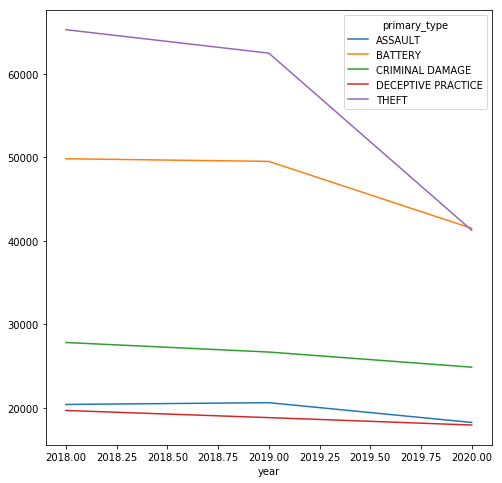

```python
pdf = df3.toPandas()
pdf = pdf.pivot(index='year', columns='primary_type', values='count')
pdf.plot(figsize=(8,8))
```

## 4. Explore by location

```python
df3_1 = df.groupBy('community_name').count().orderBy(['count'],ascending = [0])
df3_1 = df3.withColumn('rank', rank().over(Window.orderBy(desc('count'))))
df3_1.show()
```

```
+----+------------------+-----+----+
|year|      primary_type|count|rank|
+----+------------------+-----+----+
|2018|             THEFT|65275|   1|
|2019|             THEFT|62468|   2|
|2018|           BATTERY|49823|   3|
|2019|           BATTERY|49508|   4|
|2020|           BATTERY|41496|   5|
|2020|             THEFT|41263|   6|
|2018|   CRIMINAL DAMAGE|27822|   7|
|2019|   CRIMINAL DAMAGE|26681|   8|
|2020|   CRIMINAL DAMAGE|24868|   9|
|2019|           ASSAULT|20617|  10|
|2018|           ASSAULT|20406|  11|
|2018|DECEPTIVE PRACTICE|19683|  12|
|2019|DECEPTIVE PRACTICE|18829|  13|
|2020|           ASSAULT|18250|  14|
|2020|DECEPTIVE PRACTICE|17941|  15|
+----+------------------+-----+----+
```

### Use a window function to calculate a rolling 7 day sum of crimes over time within each community.

```python
# Count total crime per date
df4 = df.groupby('community_name', 'date_2').count().sort('count').orderBy(['count'], ascending = [0,0])

# Counting on rolling 7 day sum
day = lambda d:d*86400
range_d = Window.partitionBy('community_name').orderBy(col('date_2').cast('timestamp').cast('long')).rangeBetween(-day(6),0)

df4_1 = df4.withColumn('7_Days_Sum', sum('count').over(range_d))
df4_1.show()
```

```
+--------------+----------+-----+----------+
|community_name|    date_2|count|7_Days_Sum|
+--------------+----------+-----+----------+
|    North Park|2001-01-01|    2|         2|
|    North Park|2001-01-05|    1|         3|
|    North Park|2001-01-24|    1|         1|
|    North Park|2001-03-22|    1|         1|
|    North Park|2001-08-19|    1|         1|
|    North Park|2001-09-01|    1|         1|
|    North Park|2001-10-01|    1|         1|
|    North Park|2001-10-09|    1|         1|
|    North Park|2001-10-11|    1|         2|
|    North Park|2001-11-02|    1|         1|
|    North Park|2001-11-16|    1|         1|
|    North Park|2001-12-01|    2|         2|
|    North Park|2001-12-04|    1|         3|
|    North Park|2001-12-09|    1|         2|
|    North Park|2001-12-18|    1|         1|
|    North Park|2001-12-29|    1|         1|
|    North Park|2002-01-20|    1|         1|
|    North Park|2002-01-25|    1|         2|
|    North Park|2002-02-01|    1|         1|
|    North Park|2002-02-19|    1|         1|
+--------------+----------+-----+----------+
only showing top 20 rows
```

### Use window functions to calculate a 7 day moving average and cumulative sum of crimes over time within each community.

```python
df5 = df4.withColumn('7_Days_Sum', avg('count').over(range_d))
df5.withColumn('Cum_Sum', sum('count').over(Window.partitionBy('community_name').orderBy('date_2'))).show()
```

```
+--------------+----------+-----+----------+-------+
|community_name|    date_2|count|7_Days_Sum|Cum_Sum|
+--------------+----------+-----+----------+-------+
|    North Park|2001-01-01|    2|       2.0|      2|
|    North Park|2001-01-05|    1|       1.5|      3|
|    North Park|2001-01-24|    1|       1.0|      4|
|    North Park|2001-03-22|    1|       1.0|      5|
|    North Park|2001-08-19|    1|       1.0|      6|
|    North Park|2001-09-01|    1|       1.0|      7|
|    North Park|2001-10-01|    1|       1.0|      8|
|    North Park|2001-10-09|    1|       1.0|      9|
|    North Park|2001-10-11|    1|       1.0|     10|
|    North Park|2001-11-02|    1|       1.0|     11|
|    North Park|2001-11-16|    1|       1.0|     12|
|    North Park|2001-12-01|    2|       2.0|     14|
|    North Park|2001-12-04|    1|       1.5|     15|
|    North Park|2001-12-09|    1|       1.0|     16|
|    North Park|2001-12-18|    1|       1.0|     17|
|    North Park|2001-12-29|    1|       1.0|     18|
|    North Park|2002-01-20|    1|       1.0|     19|
|    North Park|2002-01-25|    1|       1.0|     20|
|    North Park|2002-02-01|    1|       1.0|     21|
|    North Park|2002-02-19|    1|       1.0|     22|
+--------------+----------+-----+----------+-------+
only showing top 20 rows
```

### Cross-tabulate Crime Types vs Location description and visualize it through a heatmap.

```python
# Cross-tabulate
cross_tab = df.crosstab('primary_type', 'location_description')
cross_tab=cross_tab.toPandas()
#cross_tab.fillna(0,inplace=True)

col=list(cross_tab.columns)
col=[text.replace("\"", "") for text in col]
cross_tab.columns=col

cross_tab = cross_tab.melt(id_vars = ['primary_type_location_description'], var_name='location_description', value_name='count')
pd.DataFrame(cross_tab.head(5), columns=cross_tab.columns)
```

|  | primary_type_location_description | location_description | count |
| --- | --- | --- | --- |
| 0 | CRIMINAL TRESPASS | CTA L PLATFORM | 0 |
| 1 | OFFENSE INVOLVING CHILDREN | CTA L PLATFORM | 0 |
| 2 | NARCOTICS | CTA L PLATFORM | 0 |
| 3 | RITUALISM | CTA L PLATFORM | 0 |
| 4 | CRIMINAL SEXUAL ASSAULT | CTA L PLATFORM | 0 |

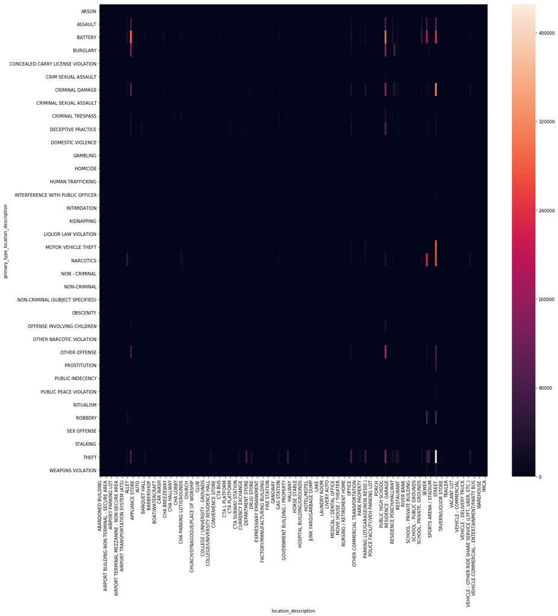

```python
# Visualize Cross-tabulate through a heatmap
heatmap=cross_tab.pivot(index="primary_type_location_description",columns="location_description", values="count")

fig = plt.figure(figsize = (20,20))
ax = fig.gca()
sns.heatmap(heatmap,ax=ax)
```

## 5. Impact of Covid-19

### Bring in daily Covid cases data from the City of Chicago data portal and load into a table chicago_covid in RCC University of Chicago Hive database.

```python
!hdfs dfs -ls /user/azizhazeinita/covid/
```

```
WARNING: log4j.properties is not found. HADOOP_CONF_DIR may be incomplete.
Java HotSpot(TM) 64-Bit Server VM warning: ignoring option MaxPermSize=512M; support was removed in 8.0
Found 1 items
-rwxr-xr-x   3 azizhazeinita azizhazeinita     113075 2022-02-26 00:27 /user/azizhazeinita/covid/chicago_covid.csv
```

```python
df2 = spark.read.csv("/user/azizhazeinita/covid/chicago_covid.csv", inferSchema=True, header=True)
```

```python
pd.DataFrame(df2.head(5), columns=df2.columns)
```

|  | Date | Cases - Total | Deaths - Total | Hospitalizations - Total | Cases - Age 0-17 | Cases - Age 18-29 | Cases - Age 30-39 | Cases - Age 40-49 | Cases - Age 50-59 | Cases - Age 60-69 | ... | Hospitalizations - Age Unknown | Hospitalizations - Female | Hospitalizations - Male | Hospitalizations - Unknown Gender | Hospitalizations - Latinx | Hospitalizations - Asian Non-Latinx | Hospitalizations - Black Non-Latinx | Hospitalizations - White Non-Latinx | Hospitalizations - Other Race Non-Latinx | Hospitalizations - Unknown Race/Ethnicity |
| --- | --- | --- | --- | --- | --- | --- | --- | --- | --- | --- | --- | --- | --- | --- | --- | --- | --- | --- | --- | --- | --- |
| 0 | 11/24/2020 | 1926 | 17 | 122 | 239 | 444 | 367 | 324 | 251 | 163 | ... | 0 | 58 | 64 | 0 | 36 | 6 | 51 | 25 | 2 | 2 |
| 1 | 03/26/2020 | 413 | 2 | 132 | 2 | 65 | 74 | 78 | 96 | 53 | ... | 0 | 57 | 75 | 0 | 27 | 1 | 81 | 19 | 4 | 0 |
| 2 | 11/06/2020 | 2793 | 10 | 124 | 342 | 800 | 573 | 412 | 336 | 217 | ... | 0 | 62 | 62 | 0 | 38 | 3 | 52 | 22 | 7 | 2 |
| 3 | 09/23/2021 | 365 | 5 | 32 | 82 | 84 | 74 | 45 | 30 | 29 | ... | 0 | 15 | 17 | 0 | 8 | 2 | 16 | 5 | 1 | 0 |
| 4 | 03/07/2021 | 173 | 4 | 14 | 16 | 42 | 39 | 33 | 24 | 11 | ... | 0 | 7 | 7 | 0 | 9 | 1 | 2 | 2 | 0 | 0 |

5 rows × 58 columns

```python
df2 = df2.withColumn("Date2",to_date(col("Date"),"MM/dd/yyyy").alias("date"))
df2.printSchema()
```

```
root
 |-- Date: string (nullable = true)
 |-- Cases - Total: integer (nullable = true)
 |-- Deaths - Total: integer (nullable = true)
 |-- Hospitalizations - Total: integer (nullable = true)
 |-- Cases - Age 0-17: integer (nullable = true)
 |-- Cases - Age 18-29: integer (nullable = true)
 |-- Cases - Age 30-39: integer (nullable = true)
 |-- Cases - Age 40-49: integer (nullable = true)
 |-- Cases - Age 50-59: integer (nullable = true)
 |-- Cases - Age 60-69: integer (nullable = true)
 |-- Cases - Age 70-79: integer (nullable = true)
 |-- Cases -  Age 80+: integer (nullable = true)
 |-- Cases - Age Unknown: integer (nullable = true)
 |-- Cases - Female: integer (nullable = true)
 |-- Cases - Male: integer (nullable = true)
 |-- Cases - Unknown Gender: integer (nullable = true)
 |-- Cases - Latinx: integer (nullable = true)
 |-- Cases - Asian Non-Latinx: integer (nullable = true)
 |-- Cases - Black Non-Latinx: integer (nullable = true)
 |-- Cases - White Non-Latinx: integer (nullable = true)
 |-- Cases - Other Race Non-Latinx: integer (nullable = true)
 |-- Cases - Unknown Race/Ethnicity: integer (nullable = true)
 |-- Deaths - Age 0-17: integer (nullable = true)
 |-- Deaths - Age 18-29: integer (nullable = true)
 |-- Deaths - Age 30-39: integer (nullable = true)
 |-- Deaths - Age 40-49: integer (nullable = true)
 |-- Deaths - Age 50-59: integer (nullable = true)
 |-- Deaths - Age 60-69: integer (nullable = true)
 |-- Deaths - Age 70-79: integer (nullable = true)
 |-- Deaths - Age 80+: integer (nullable = true)
 |-- Deaths - Age Unknown: integer (nullable = true)
 |-- Deaths - Female: integer (nullable = true)
 |-- Deaths - Male: integer (nullable = true)
 |-- Deaths - Unknown Gender: integer (nullable = true)
 |-- Deaths - Latinx: integer (nullable = true)
 |-- Deaths - Asian Non-Latinx: integer (nullable = true)
 |-- Deaths - Black Non-Latinx: integer (nullable = true)
 |-- Deaths - White Non-Latinx: integer (nullable = true)
 |-- Deaths - Other Race Non-Latinx: integer (nullable = true)
 |-- Deaths - Unknown Race/Ethnicity: integer (nullable = true)
 |-- Hospitalizations - Age 0-17: integer (nullable = true)
 |-- Hospitalizations - Age 18-29: integer (nullable = true)
 |-- Hospitalizations - Age 30-39: integer (nullable = true)
 |-- Hospitalizations - Age 40-49: integer (nullable = true)
 |-- Hospitalizations - Age 50-59: integer (nullable = true)
 |-- Hospitalizations - Age 60-69: integer (nullable = true)
 |-- Hospitalizations - Age 70-79: integer (nullable = true)
 |-- Hospitalizations - Age 80+: integer (nullable = true)
 |-- Hospitalizations - Age Unknown: integer (nullable = true)
 |-- Hospitalizations - Female: integer (nullable = true)
 |-- Hospitalizations - Male: integer (nullable = true)
 |-- Hospitalizations - Unknown Gender: integer (nullable = true)
 |-- Hospitalizations - Latinx: integer (nullable = true)
 |-- Hospitalizations - Asian Non-Latinx: integer (nullable = true)
 |-- Hospitalizations - Black Non-Latinx: integer (nullable = true)
 |-- Hospitalizations - White Non-Latinx: integer (nullable = true)
 |-- Hospitalizations - Other Race Non-Latinx: integer (nullable = true)
 |-- Hospitalizations - Unknown Race/Ethnicity: integer (nullable = true)
 |-- Date2: date (nullable = true)
```

### Create summarized daily total counts of the daily crime data by crime type.

```python
daily_crime = df.groupby('year','date_2','month_year','primary_type').count().sort("count").orderBy(['date_2','count'], ascending=[1,0])
daily_crime.show()
```

```
+----+----------+----------+--------------------+-----+
|year|    date_2|month_year|        primary_type|count|
+----+----------+----------+--------------------+-----+
|2001|2001-01-01|   2001-01|               THEFT|  412|
|2001|2001-01-01|   2001-01|             BATTERY|  296|
|2001|2001-01-01|   2001-01|     CRIMINAL DAMAGE|  233|
|2001|2001-01-01|   2001-01|       OTHER OFFENSE|  167|
|2001|2001-01-01|   2001-01|OFFENSE INVOLVING...|   98|
|2001|2001-01-01|   2001-01|           NARCOTICS|   97|
|2001|2001-01-01|   2001-01|  DECEPTIVE PRACTICE|   92|
|2001|2001-01-01|   2001-01|             ASSAULT|   70|
|2001|2001-01-01|   2001-01|            BURGLARY|   66|
|2001|2001-01-01|   2001-01|         SEX OFFENSE|   65|
|2001|2001-01-01|   2001-01| MOTOR VEHICLE THEFT|   60|
|2001|2001-01-01|   2001-01|             ROBBERY|   41|
|2001|2001-01-01|   2001-01| CRIM SEXUAL ASSAULT|   38|
|2001|2001-01-01|   2001-01|   WEAPONS VIOLATION|   32|
|2001|2001-01-01|   2001-01|   CRIMINAL TRESPASS|   29|
|2001|2001-01-01|   2001-01|        PROSTITUTION|    5|
|2001|2001-01-01|   2001-01|PUBLIC PEACE VIOL...|    5|
|2001|2001-01-01|   2001-01|CRIMINAL SEXUAL A...|    3|
|2001|2001-01-01|   2001-01|LIQUOR LAW VIOLATION|    3|
|2001|2001-01-01|   2001-01|          KIDNAPPING|    2|
+----+----------+----------+--------------------+-----+
only showing top 20 rows
```

### Join daily total covid cases and death data with daily chicago crimes data starting Jan 2020.

```python
daily_covid = df2.select('Date2', 'Cases - Total', 'Deaths - Total')
daily_covid.show()
```

```
+----------+-------------+--------------+
|     Date2|Cases - Total|Deaths - Total|
+----------+-------------+--------------+
|2020-11-24|         1926|            17|
|2020-03-26|          413|             2|
|2020-11-06|         2793|            10|
|2021-09-23|          365|             5|
|2021-03-07|          173|             4|
|2021-08-04|          499|             3|
|2020-07-03|          175|             5|
|2021-01-09|          781|            17|
|2020-09-01|          330|             3|
|2021-04-13|          677|             4|
|2020-10-01|          364|             4|
|2021-09-07|          577|             3|
|2020-12-12|          915|            21|
|2021-04-20|          565|             5|
|2021-01-19|         1085|            19|
|2021-08-05|          479|             2|
|2021-10-11|          321|             4|
|2021-06-19|           30|             2|
|2021-12-06|         1215|             6|
|2021-08-10|          535|             4|
+----------+-------------+--------------+
only showing top 20 rows
```

```python
daily_covid.select(min('Date2'))
```

| min(Date2) |
| --- |
| 2020-03-01 |

```python
# From the code above, we can see that the earliest date of covid dataset is on March 2020, so we can't join the data from Jan 2020
df_join = daily_covid.join(daily_crime, (daily_covid["Date2"]== daily_crime["date_2"]) & (daily_crime["date_2"] >= '2020-01-01'), "left")
pd.DataFrame(df_join.head(5), columns=df_join.columns)
```

|  | Date2 | Cases - Total | Deaths - Total | year | date_2 | month_year | primary_type | count |
| --- | --- | --- | --- | --- | --- | --- | --- | --- |
| 0 | 2021-03-07 | 173 | 4 | 2021 | 2021-03-07 | 2021-03 | WEAPONS VIOLATION | 28 |
| 1 | 2021-03-07 | 173 | 4 | 2021 | 2021-03-07 | 2021-03 | ROBBERY | 17 |
| 2 | 2021-03-07 | 173 | 4 | 2021 | 2021-03-07 | 2021-03 | NARCOTICS | 13 |
| 3 | 2021-03-07 | 173 | 4 | 2021 | 2021-03-07 | 2021-03 | BURGLARY | 12 |
| 4 | 2021-03-07 | 173 | 4 | 2021 | 2021-03-07 | 2021-03 | CRIMINAL TRESPASS | 11 |

### Perform an analysis in PySpark on how Covid-19 has impacted various types of crimes compared to previous years.

```python
df_join_sum = df_join.groupBy("year", "primary_type").agg((F.sum("count")).alias('Sum_Count'), F.sum("Cases - Total").alias('Sum_Case_Total'), (F.sum("Deaths - Total").alias('Sum_Deaths_Total'))).orderBy(['year'], ascending=[1])
df_join_sum.show()
```

```
+----+--------------------+---------+--------------+----------------+
|year|        primary_type|Sum_Count|Sum_Case_Total|Sum_Deaths_Total|
+----+--------------------+---------+--------------+----------------+
|null|                null|     null|          5761|              97|
|2020|             BATTERY|    34503|        208989|            4368|
|2020|     CRIMINAL DAMAGE|    21334|        208989|            4368|
|2020|               THEFT|    32486|        208989|            4368|
|2020|           OBSCENITY|       47|         29068|             615|
|2020|INTERFERENCE WITH...|      417|        143173|            2771|
|2020|   WEAPONS VIOLATION|     7478|        208989|            4368|
|2020|CONCEALED CARRY L...|      120|         60661|            1187|
|2020|            BURGLARY|     7392|        208989|            4368|
|2020|OFFENSE INVOLVING...|     1504|        206709|            4334|
|2020|LIQUOR LAW VIOLATION|      107|         29430|             450|
|2020|             ROBBERY|     6491|        208989|            4368|
|2020|   HUMAN TRAFFICKING|        3|          1817|              41|
|2020|OTHER NARCOTIC VI...|        3|           177|               6|
|2020|           RITUALISM|        1|          2464|              21|
|2020|       OTHER OFFENSE|     9895|        208989|            4368|
|2020|    PUBLIC INDECENCY|        7|          4218|              81|
|2020|            HOMICIDE|      717|        172566|            3602|
|2020|        INTIMIDATION|      140|         70041|            1223|
|2020|            STALKING|      169|         88342|            1559|
+----+--------------------+---------+--------------+----------------+
only showing top 20 rows
```

```python
df_join_pandas = df_join.toPandas()
```

### Year-to-year comparison on how Covid-19 has impacted various types of crimes.

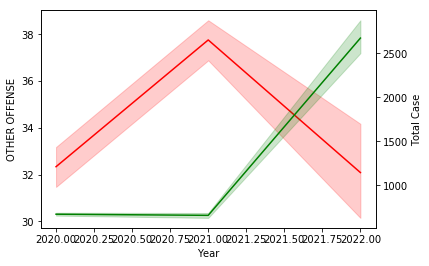

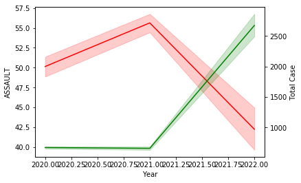

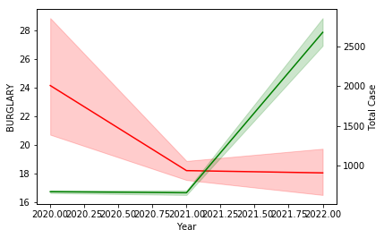

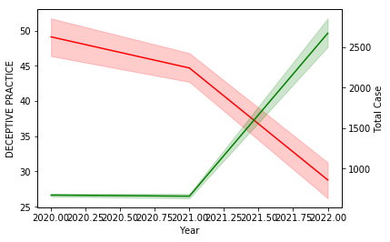

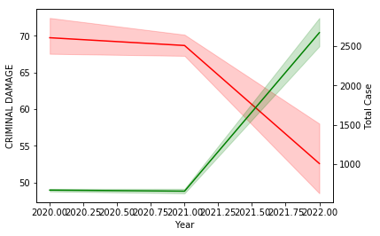

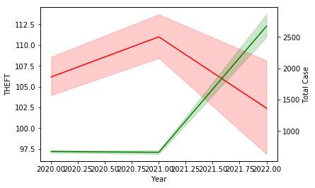

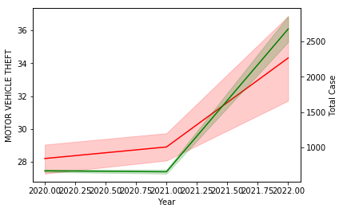

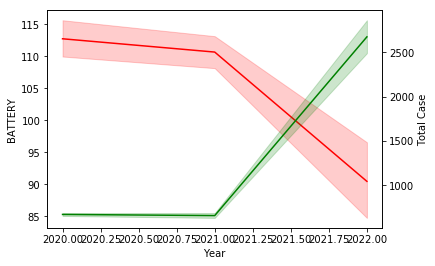

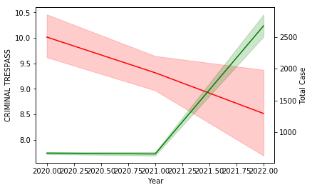

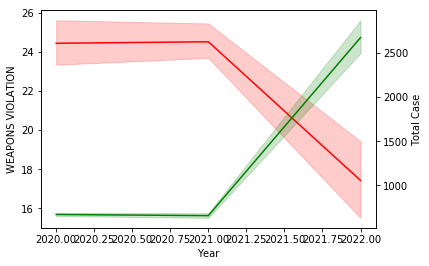

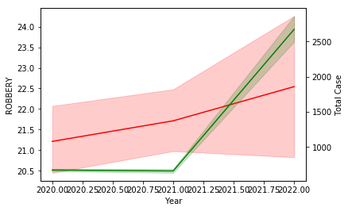

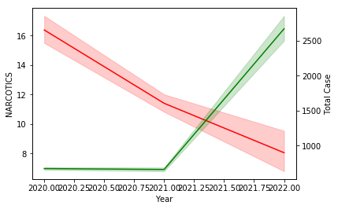

[20 more figures not shown]

```python
c=df_join_pandas["primary_type"].value_counts()
count=list(c.index)

for i in count:
    df_join_pandas_a=df_join_pandas[df_join_pandas["primary_type"]==i]
    ax =sns.lineplot(data=df_join_pandas_a,x="year",y="count", color="r")
    ax2 = plt.twinx()
    sns.lineplot(data=df_join_pandas,x="year",y="Cases - Total", color="g", ax=ax2)
    ax.set(xlabel='Year', ylabel=i)
    ax2.set(ylabel="Total Case")
    plt.show()
```

### Month-to-month comparison on how Covid-19 has impacted various types of crimes.

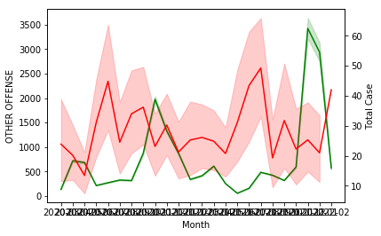

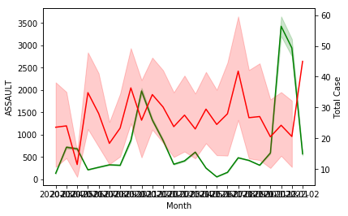

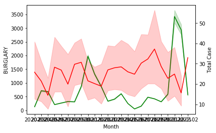

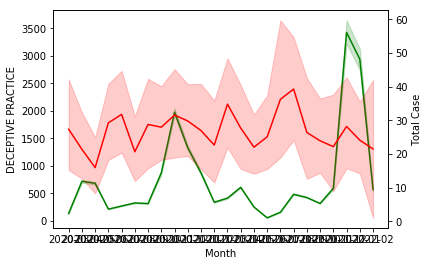

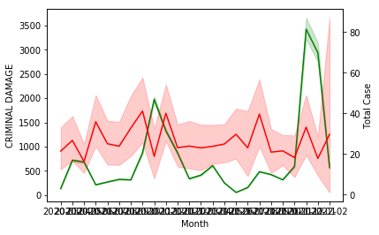

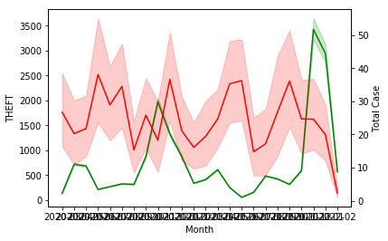

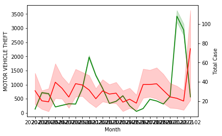

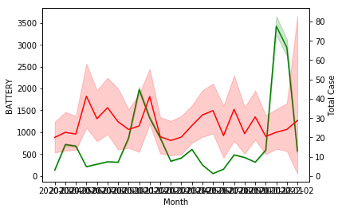

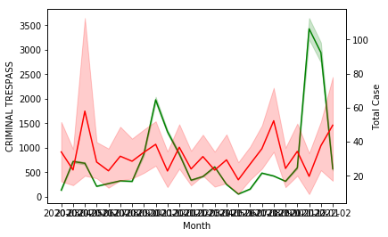

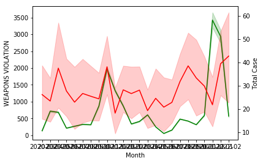

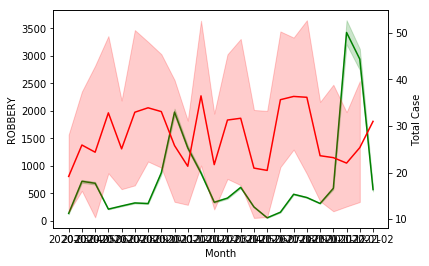

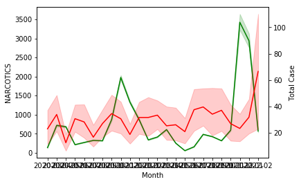

[20 more figures not shown]

```python
df_join_pandas.sort_values(by="month_year",inplace=True)
c=df_join_pandas["primary_type"].value_counts()
count=list(c.index)

for i in count:
    df_join_pandas_a = df_join_pandas[daily_crime_pandas["primary_type"] == i]
    ax =sns.lineplot(data = df_join_pandas, x = "month_year", y = "Cases - Total", color = "g")
    ax2 = plt.twinx()
    sns.lineplot(data = df_join_pandas_a, x = "month_year", y = "count", color = "r", ax = ax2)
    ax.set(xlabel = 'Month', ylabel = i)
    ax2.set(ylabel = "Total Case")
    plt.figure(figsize=(200,200))
    plt.show()
```

### Year-to-year comparison on how Covid-19 has impacted number of crimes grouped by various types of crimes (Bar Chart)

```python
df_join_sum_pandas = df_join_sum.toPandas()
df_join_sum_pandas.plot(figsize=(60,300), kind='barh', x="primary_type", grid=True, rot="0")
```

[figure not shown]